# Wizualizacja danych II

31 05 2026

## Przypomnienie

Materiały: https://github.com/michbur/WizualizacjaDanych2025-2026L

Mail: michalburdukiewicz@gmail.com

## Plan spotkań

1. Czym są wizualizacje danych?
2. Gramatyka grafiki.
3. Błędy w wizualizacjach danych.
4. Narzędzia do wizualizacji danych.
5. **Efektywne projektowanie dashboardów.**
6. **Zaaawansowane wizualizacje danych.**

## Polaris

## Twórcy

“Polaris, an interface for exploring large multi-dimensional databases that extends the well-known Pivot Table interface first popularized by Microsoft Excel.”

http://www.graphics.stanford.edu/projects/polaris/

Źródło: *Polaris: a system for query, analysis, and visualization of multidimensional databases*, Proceeding IEEE InfoVis’00 reprinted Commun. ACM 51, 11 (November 2008), 75-84.

Twórcy:

- Chris Stolte,
- Diane Tang,
- Pat Hanrahan.

## Założenie

1. Interfejs do eksploracji danych.
2. Zróżnicowane metody wizualizacji danych.
3. Wizualizacje o wysokiej wymiarowości i gęstości informacji.

## Tabelaryczne ujęcie danych

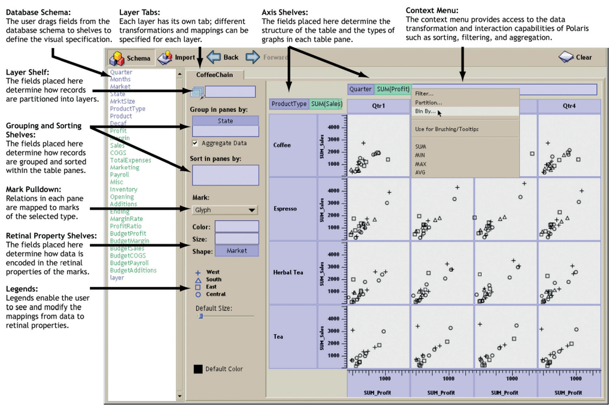

## Tabelaryczne ujęcie danych

Zalety:

- wielowymiarowość,
- swojskość,
- łatwość porównań (tabele generują wiele małych przedstawień informacji, które łatwo ze sobą porównywać w celu wskazania trendów/korelacji pomiędzy wymiarami).

## Tabelaryczne ujęcie danych

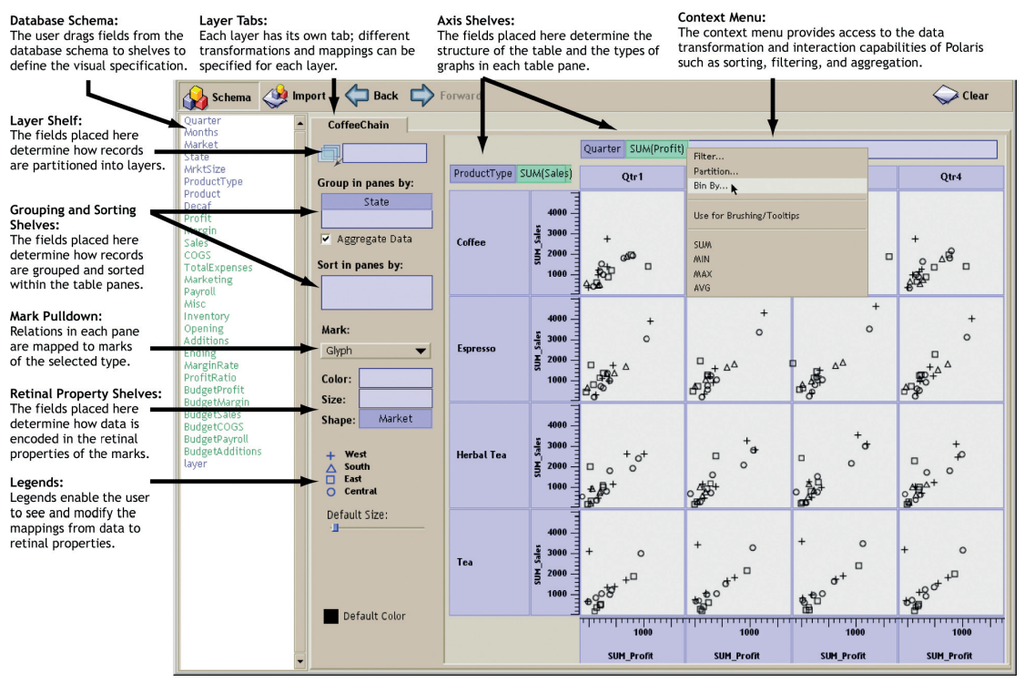

## Filozofia Tableau

[video not shown]

## Efektywne projektowanie dashboardów

## Pytania projektowe

1. Co użytkownik chce zrobić za pomocą dashbaordu?
   - wykryć/wyjaśnić/zdecydować?
2. Jaka jest kluczowa akcja użytkownika?
   - odczyt/filtr/drill-down/porównanie/wyszukiwanie
3. Ile czasu użytkownik poświęca na typowe użycie dashboardu?
   - poniżej minuty/5 minut/ponad 5 minut
4. Jaka jest tolerancja opóźnienia w aktualizacji danych?
   - minuta/dzień/miesiąc

## Rodzaje dashboardów

- analityczne,
- operacyjne.

Źródło: https://uxplanet.org/

## Analityczny dashboard

[figure not shown]

Źródło: https://uxplanet.org/

## Operacyjny dashboard

[figure not shown]

Źródło: https://uxplanet.org/

## Wybór typu dashboardu

| Pytania | Operacyjny | Analityczny |
| --- | --- | --- |
| Co użytkownik chce zrobić za pomocą dashbaordu | wykryć | wyjaśnić/zdecydować |
| Jaka jest kluczowa akcja użytkownika? | odczyt/wyszukiwanie | filtr/drill-down/porównanie |
| Ile czasu użytkownik poświęca na typowe użycie dashboardu? | mniej | więcej |
| Jaka jest tolerancja opóźnienia? | mniejsza | większa |

## Układ treści

[figure not shown]

Źródło: https://www.sisense.com/blog/4-design-principles-creating-better-dashboards/

## Właściwy dobór wizualizacji do danych

[figure not shown]

Źródło: https://www.tapclicks.com/resources/blog/the-ultimate-guide-to-data-visualization/.

## Interakcja

“*Only 10–15% of people click on buttons*”.

Gregor Aisch, New York Times, podczas Information+ Conference, 2016.

## Interakcja

“*15% of readers isn’t nobody*”.

Gregor Aisch, New York Times, 2017.

## Zastosowanie interakcji

Kluczowa informacja na wykresie nie może być skryta przed użytkownikiem za pomocą interakcji.

Interakcje powinny zawierać wyłącznie informacje doprecyzowujące główny przekaz.

## Interaktywność

Zbędna interaktywność wymaga od nas akcji w celu uzyskania podstawowych informacji.

[figure not shown]

Źródło: [Data + design](https://trinachi.github.io/data-design-builds/titlepage01.html)

## Interaktywność

Poprawnie użyta interaktywność ułatwia eksplorację danych.

[figure not shown]

Źródło: [Data + design](https://trinachi.github.io/data-design-builds/titlepage01.html)

## Przykład: tooltipy

[interactive chart not shown]

Cel wizualizacji: zależność długości pręcika od długości słupka w podziale na gatunki irysów.

## Przykład: tooltipy

[interactive chart not shown]

Cel wizualizacji: zależność długości pręcika od długości słupka w podziale na gatunki irysów.

## Przykład: tooltipy

[interactive chart not shown]

Cel wizualizacji: zależność długości pręcika od długości słupka w podziale na gatunki irysów.

## Przykład: tooltipy

[interactive chart not shown]

Cel wizualizacji: zależność długości pręcika od długości słupka w podziale na gatunki irysów.

## Przykład: zbliżenie

[interactive chart not shown]

Cel wizualizacji: zależność długości pręcika od długości słupka w podziale na gatunki irysów.

## Przykład: zbliżenie

[interactive chart not shown]

Cel wizualizacji: zależność długości pręcika od długości słupka w podziale na gatunki irysów.

## Czy warto wykorzystywać interakcję?

Badania wskazują, że interakcja pozwala bardziej zaangażować odbiorców oraz sprzyja retencji informacji.

Greussing, E., Kessler, S. H., & Boomgaarden, H. G. (2020). Learning From Science News via Interactive and Animated Data Visualizations: An Investigation Combining Eye Tracking, Online Survey, and Cued Retrospective Reporting. Science Communication, 42(6), 803–828. https://doi.org/10.1177/1075547020962100

## Zaawansowane wizualizacje danych

## Wybór wykresu

Nie wszystko można pokazać wykresem słupkowym.

## Wybór wykresu

- https://www.data-to-viz.com/
- https://datavizcatalogue.com/

## Główne wyzwania przy wyborze wykresu

1. Hierarchie.
2. Wiele wymiarów w tym samym momencie.
3. Przepływy.

## Mapa drzewa

[figure not shown]

Źródło: MS Office.

## Mapa drzewa

Mapa drzewa (treemap): wizualizacja hierarchicznych danych za pomocą zagnieźdżonych obiektów.

## Wykresy radarowe

[figure not shown]

Źródło: edrawsoft.com

## Wykresy radarowe

Wykres radarowy (radar plot): porównanie kilku obiektów pod względem wielu charakterystyk.

## Wykres trójkątny

[figure not shown]

## Wykres trójkątny

[figure not shown]

Źródło: https://fivethirtyeight.com/features/the-worst-tweeter-in-politics-isnt-trump/

## Wykres trójkątny

Wykres trójkątny (ternary plot): przedstawienie w dwóch wymiarach trzech zmiennych ciągłych oraz propocji między nimi.

## Diagram Sankeya

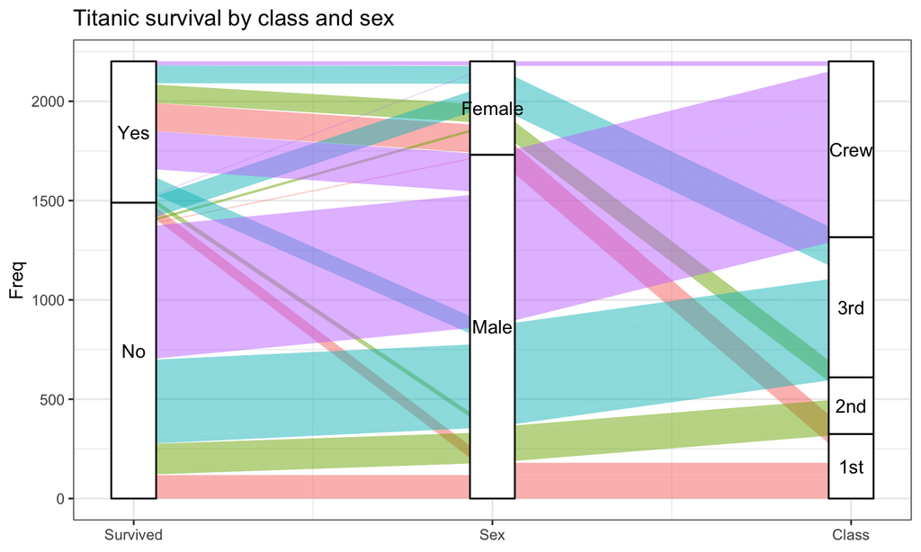

## Diagram Sankeya

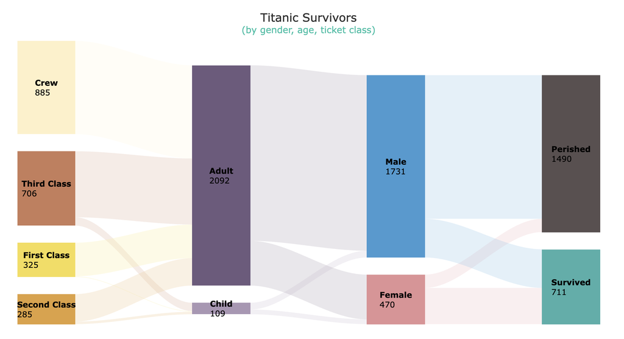

Źródło: https://www.anychart.com/de/products/anychart/gallery/Sankey_Diagram/Titanic_Survivors.php

## Diagram Sankeya

Diagram Sankeya (alluvial plot): przestawienie przepływu obiektów między poszczególnymi stanami.

Przykład: https://www.appeconomyinsights.com/

## Wykres strunowy

[figure not shown]

Źródło: https://www.data-to-viz.com/

## Wykres strunowe

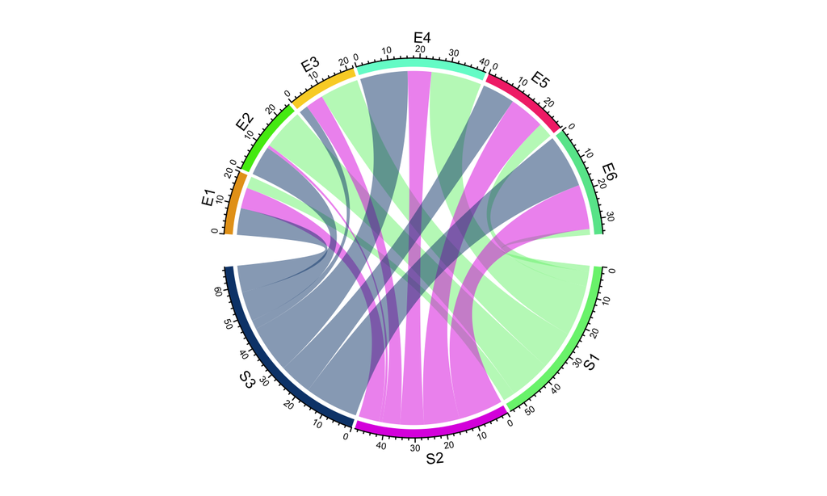

## Wykres strunowy

Wykres strunowy (chord diagram): przedstawienie zależności/przepływów między wieloma parami stanów (zależności wiele do wielu).

## Podsumowanie: wizualizacje jako opowieść

## Scrollytelling

Portmanteau “storytelling” i “scrolling” - angażujące przedstawienia treści, gdzie narracja zależy od scrollowania.

Przykłady: https://pudding.cool/2018/08/pockets/

## Wizualizacje

[figure not shown]

Źródło: informationisbeautiful.net